# EH19V

# IND 9

**TABLAS Y GRAFICOS**

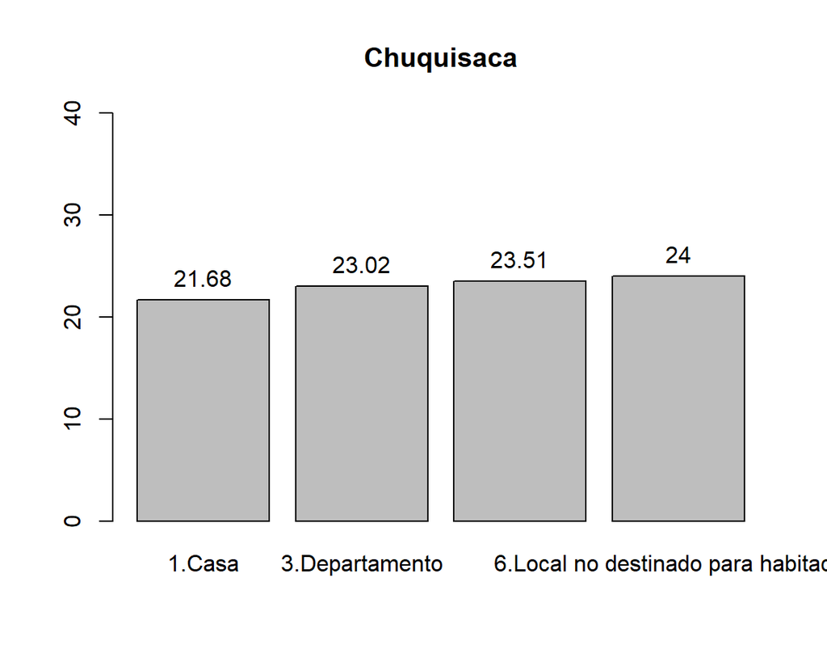

```
Table: Chuquisaca

|   |Group.1    |Group.2                                |        x|
|:--|:----------|:--------------------------------------|--------:|
|1  |Chuquisaca |1.Casa                                 | 21.67980|
|16 |Chuquisaca |3.Departamento                         | 23.02381|
|25 |Chuquisaca |4.Cuarto(s) o habitacion(es) suelta(s) | 23.50746|
|36 |Chuquisaca |6.Local no destinado para habitación   | 24.00000|
```

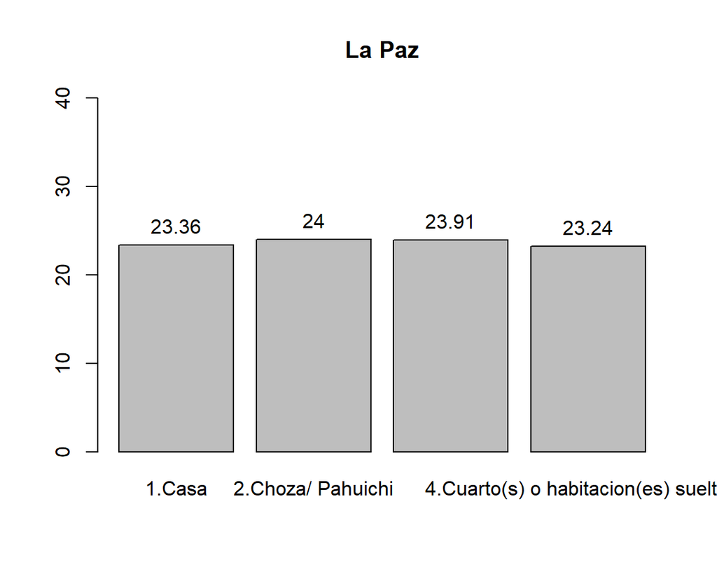

```
Table: La Paz

|   |Group.1 |Group.2                                |        x|
|:--|:-------|:--------------------------------------|--------:|
|2  |La Paz  |1.Casa                                 | 23.36017|
|10 |La Paz  |2.Choza/ Pahuichi                      | 24.00000|
|17 |La Paz  |3.Departamento                         | 23.90977|
|26 |La Paz  |4.Cuarto(s) o habitacion(es) suelta(s) | 23.23913|
```

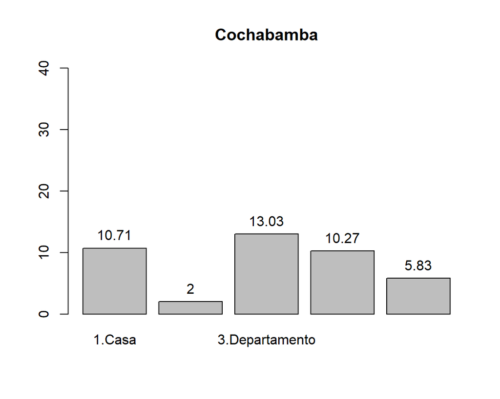

```
Table: Cochabamba

|   |Group.1    |Group.2                                 |         x|
|:--|:----------|:---------------------------------------|---------:|
|3  |Cochabamba |1.Casa                                  | 10.709804|
|11 |Cochabamba |2.Choza/ Pahuichi                       |  2.000000|
|18 |Cochabamba |3.Departamento                          | 13.025317|
|27 |Cochabamba |4.Cuarto(s) o habitacion(es) suelta(s)  | 10.274854|
|34 |Cochabamba |5.Vivienda improvisada o vivienda móvil |  5.833333|
```

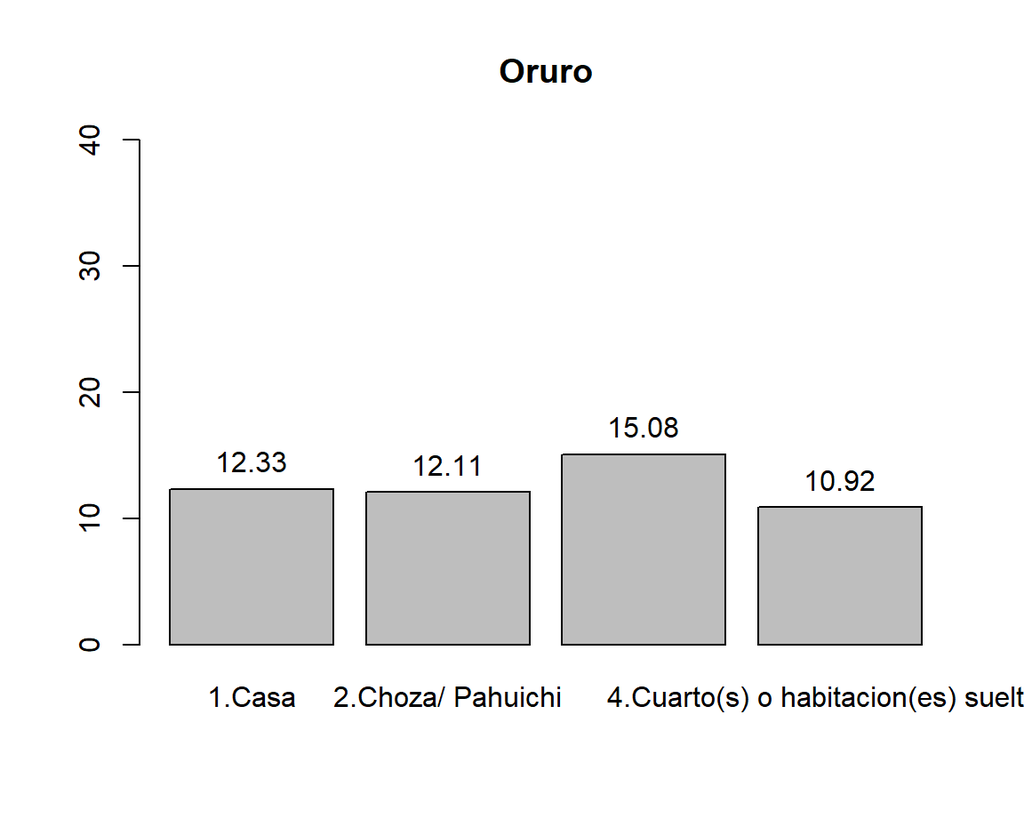

```
Table: Oruro

|   |Group.1 |Group.2                                |        x|
|:--|:-------|:--------------------------------------|--------:|
|4  |Oruro   |1.Casa                                 | 12.32981|
|12 |Oruro   |2.Choza/ Pahuichi                      | 12.11111|
|19 |Oruro   |3.Departamento                         | 15.07692|
|28 |Oruro   |4.Cuarto(s) o habitacion(es) suelta(s) | 10.91549|
```

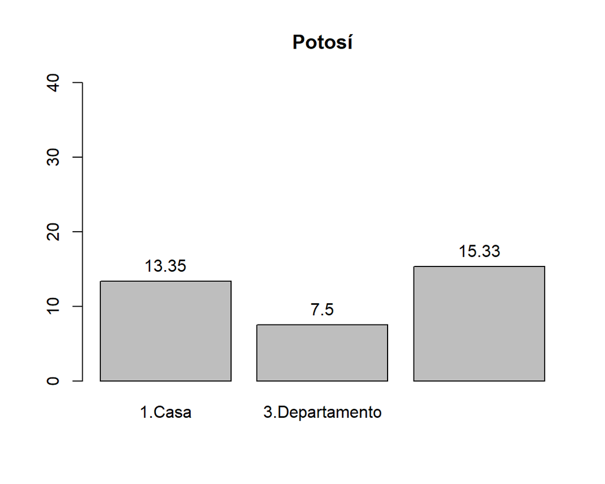

```
Table: Potosí

|   |Group.1 |Group.2                                |        x|
|:--|:-------|:--------------------------------------|--------:|
|5  |Potosí  |1.Casa                                 | 13.35354|
|20 |Potosí  |3.Departamento                         |  7.50000|
|29 |Potosí  |4.Cuarto(s) o habitacion(es) suelta(s) | 15.33333|
```

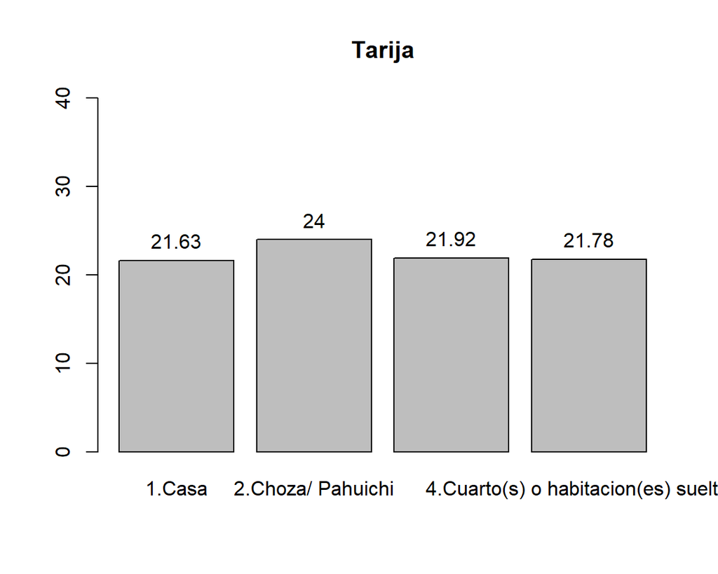

```
Table: Tarija

|   |Group.1 |Group.2                                |        x|
|:--|:-------|:--------------------------------------|--------:|
|6  |Tarija  |1.Casa                                 | 21.63466|
|13 |Tarija  |2.Choza/ Pahuichi                      | 24.00000|
|21 |Tarija  |3.Departamento                         | 21.92308|
|30 |Tarija  |4.Cuarto(s) o habitacion(es) suelta(s) | 21.78125|
```

**FICHA TECNICA**

9.RELACIÓN ENTRE LAS HORAS AL DÍA QUE SE DISPONE DEL SERVICIO DE AGUA (11) SEGÚN TIPO DE VIVIENDA

*NOMBRE DEL INDICADOR:* Tiempo de disposición de agua según el Tipo de Vivienda. *SIGLA DEL INDICADOR:* Viv_9 *OBJETIVO:* Determinar el promedio de las horas al día que disponen las viviendas del servicio de agua según el tipo de vivienda por departamento. *VARIABLES:* La construcción del indicador considera dos variables (pregunta) del cuestionario.

- Generalmente, ¿cuántas horas al día dispone del servicio de agua?
- depto

*DESCRIPCIÓN DEL INDICADOR:* El indicador refleja el promedio del tiempo en horas al día que disponen las viviendas del agua según el tipo de vivienda, para cada departamento. *MÉTODO DE MEDICIÓN:* La medición se realizará a través de la variable horas/día de agua, donde se obtendrá tales datos, a la vez esta será relacionada con el tipo de vivienda, esto nos ayudará a conocer el promedio de las horas/día de agua de acuerdo al tipo de vivienda. *FÓRMULA DE CÁLCULO:*
$$u_i= \sum_{i=1}^{n} X_i/n$$
Donde:

xi = Lo datos

ui= Es el promedio.

n = Es el número total de observaciones.

**ANÁLISIS**

- Por ejemplo podemos analizar por algunos departamentos.
- La distribución promedio de horas al día que disponen las viviendas del servicio de agua en el departamento de La Paz, tiene un tipo de comportamiento uniforme, con relación a los tipos de vivienda.
- La distribución promedio de horas al día que disponen las viviendas del servicio de agua en el departamento de Cochabamba, tiene un tipo de comportamiento creciente y decreciente, con relación a los tipos de vivienda.
- En el departamento de Potosí el promedio de horas al día que dispone del servicio de agua en el tipo de vivienda casa es menos al tipo de vivienda “Cuarto(s) o habitación(es) suelta(s)”.

# IND 10

### TABLA

```
Table: Chuquisaca

|   |Var1       |Var2                            |   Freq|
|:--|:----------|:-------------------------------|------:|
|1  |Chuquisaca |1.LEÑA                          | 25.054|
|10 |Chuquisaca |2.GUANO/BOSTA O TAQUIA          |  1.080|
|19 |Chuquisaca |3.GAS LICUADO (garrafa)         | 49.136|
|28 |Chuquisaca |4.GAS NATURAL POR RED (cañería) | 23.650|
|37 |Chuquisaca |5.OTRO (Especifique)            |  0.000|
|46 |Chuquisaca |6.ELECTRICIDAD                  |  0.108|
|55 |Chuquisaca |7.NO COCINA                     |  0.972|


Table: La Paz

|   |Var1   |Var2                            |   Freq|
|:--|:------|:-------------------------------|------:|
|2  |La Paz |1.LEÑA                          |  2.632|
|11 |La Paz |2.GUANO/BOSTA O TAQUIA          |  0.208|
|20 |La Paz |3.GAS LICUADO (garrafa)         | 51.524|
|29 |La Paz |4.GAS NATURAL POR RED (cañería) | 43.698|
|38 |La Paz |5.OTRO (Especifique)            |  0.035|
|47 |La Paz |6.ELECTRICIDAD                  |  0.796|
|56 |La Paz |7.NO COCINA                     |  1.108|


Table: Cochabamba

|   |Var1       |Var2                            |   Freq|
|:--|:----------|:-------------------------------|------:|
|3  |Cochabamba |1.LEÑA                          |  6.335|
|12 |Cochabamba |2.GUANO/BOSTA O TAQUIA          |  0.000|
|21 |Cochabamba |3.GAS LICUADO (garrafa)         | 57.566|
|30 |Cochabamba |4.GAS NATURAL POR RED (cañería) | 33.318|
|39 |Cochabamba |5.OTRO (Especifique)            |  0.000|
|48 |Cochabamba |6.ELECTRICIDAD                  |  0.137|
|57 |Cochabamba |7.NO COCINA                     |  2.644|


Table: Oruro

|   |Var1  |Var2                            |   Freq|
|:--|:-----|:-------------------------------|------:|
|4  |Oruro |1.LEÑA                          | 11.187|
|13 |Oruro |2.GUANO/BOSTA O TAQUIA          |  0.913|
|22 |Oruro |3.GAS LICUADO (garrafa)         | 56.735|
|31 |Oruro |4.GAS NATURAL POR RED (cañería) | 28.995|
|40 |Oruro |5.OTRO (Especifique)            |  0.000|
|49 |Oruro |6.ELECTRICIDAD                  |  0.228|
|58 |Oruro |7.NO COCINA                     |  1.941|


Table: Potosí

|   |Var1   |Var2                            |   Freq|
|:--|:------|:-------------------------------|------:|
|5  |Potosí |1.LEÑA                          | 30.291|
|14 |Potosí |2.GUANO/BOSTA O TAQUIA          |  0.529|
|23 |Potosí |3.GAS LICUADO (garrafa)         | 46.825|
|32 |Potosí |4.GAS NATURAL POR RED (cañería) | 20.635|
|41 |Potosí |5.OTRO (Especifique)            |  0.000|
|50 |Potosí |6.ELECTRICIDAD                  |  0.000|
|59 |Potosí |7.NO COCINA                     |  1.720|


Table: Tarija

|   |Var1   |Var2                            |   Freq|
|:--|:------|:-------------------------------|------:|
|6  |Tarija |1.LEÑA                          | 10.406|
|15 |Tarija |2.GUANO/BOSTA O TAQUIA          |  0.496|
|24 |Tarija |3.GAS LICUADO (garrafa)         | 46.977|
|33 |Tarija |4.GAS NATURAL POR RED (cañería) | 37.859|
|42 |Tarija |5.OTRO (Especifique)            |  0.000|
|51 |Tarija |6.ELECTRICIDAD                  |  0.000|
|60 |Tarija |7.NO COCINA                     |  4.262|


Table: Santa Cruz

|   |Var1       |Var2                            |   Freq|
|:--|:----------|:-------------------------------|------:|
|7  |Santa Cruz |1.LEÑA                          |  5.740|
|16 |Santa Cruz |2.GUANO/BOSTA O TAQUIA          |  0.000|
|25 |Santa Cruz |3.GAS LICUADO (garrafa)         | 62.692|
|34 |Santa Cruz |4.GAS NATURAL POR RED (cañería) | 25.433|
|43 |Santa Cruz |5.OTRO (Especifique)            |  0.000|
|52 |Santa Cruz |6.ELECTRICIDAD                  |  0.000|
|61 |Santa Cruz |7.NO COCINA                     |  6.136|


Table: Beni

|   |Var1 |Var2                            |   Freq|
|:--|:----|:-------------------------------|------:|
|8  |Beni |1.LEÑA                          | 17.496|
|17 |Beni |2.GUANO/BOSTA O TAQUIA          |  0.000|
|26 |Beni |3.GAS LICUADO (garrafa)         | 70.739|
|35 |Beni |4.GAS NATURAL POR RED (cañería) |  2.413|
|44 |Beni |5.OTRO (Especifique)            |  0.000|
|53 |Beni |6.ELECTRICIDAD                  |  0.000|
|62 |Beni |7.NO COCINA                     |  9.351|


Table: Pando

|   |Var1  |Var2                            |   Freq|
|:--|:-----|:-------------------------------|------:|
|9  |Pando |1.LEÑA                          | 14.179|
|18 |Pando |2.GUANO/BOSTA O TAQUIA          |  0.000|
|27 |Pando |3.GAS LICUADO (garrafa)         | 77.985|
|36 |Pando |4.GAS NATURAL POR RED (cañería) |  0.933|
|45 |Pando |5.OTRO (Especifique)            |  0.000|
|54 |Pando |6.ELECTRICIDAD                  |  0.187|
|63 |Pando |7.NO COCINA                     |  6.716|
```

### GRAFICA

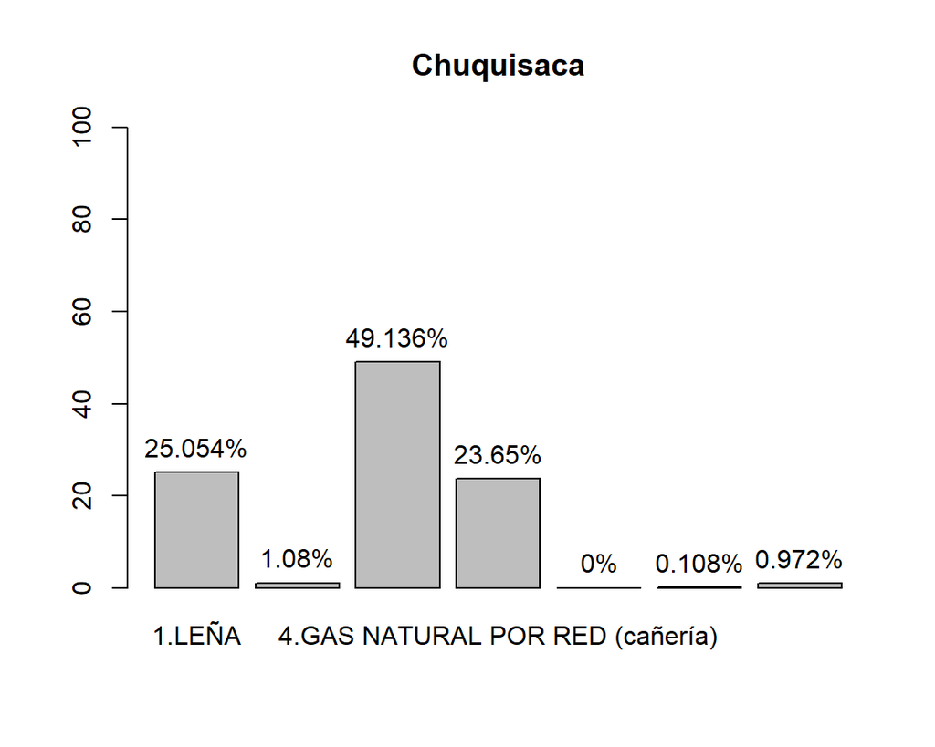

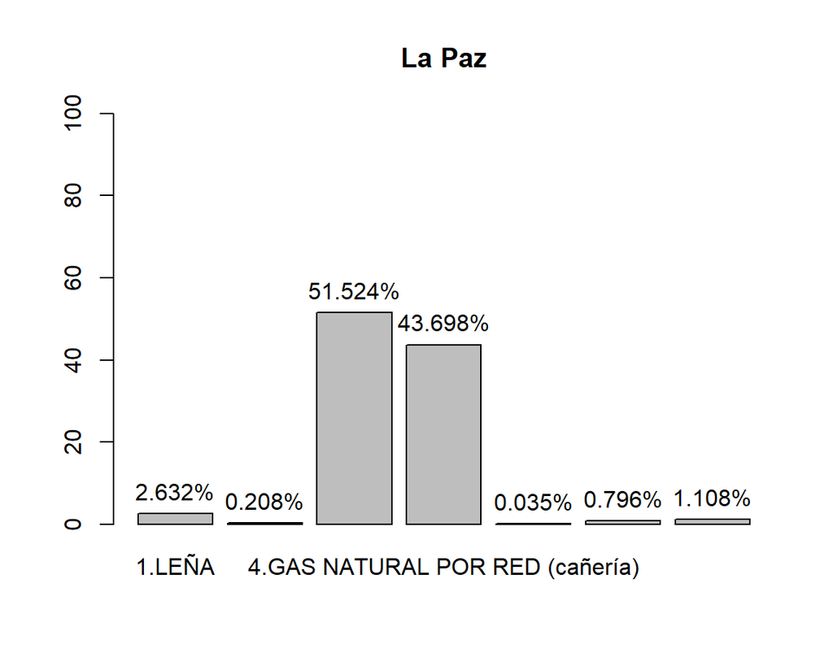

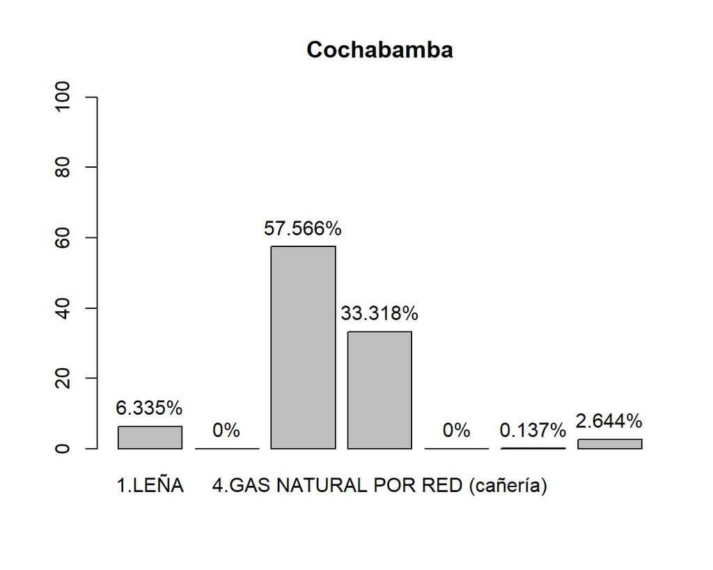

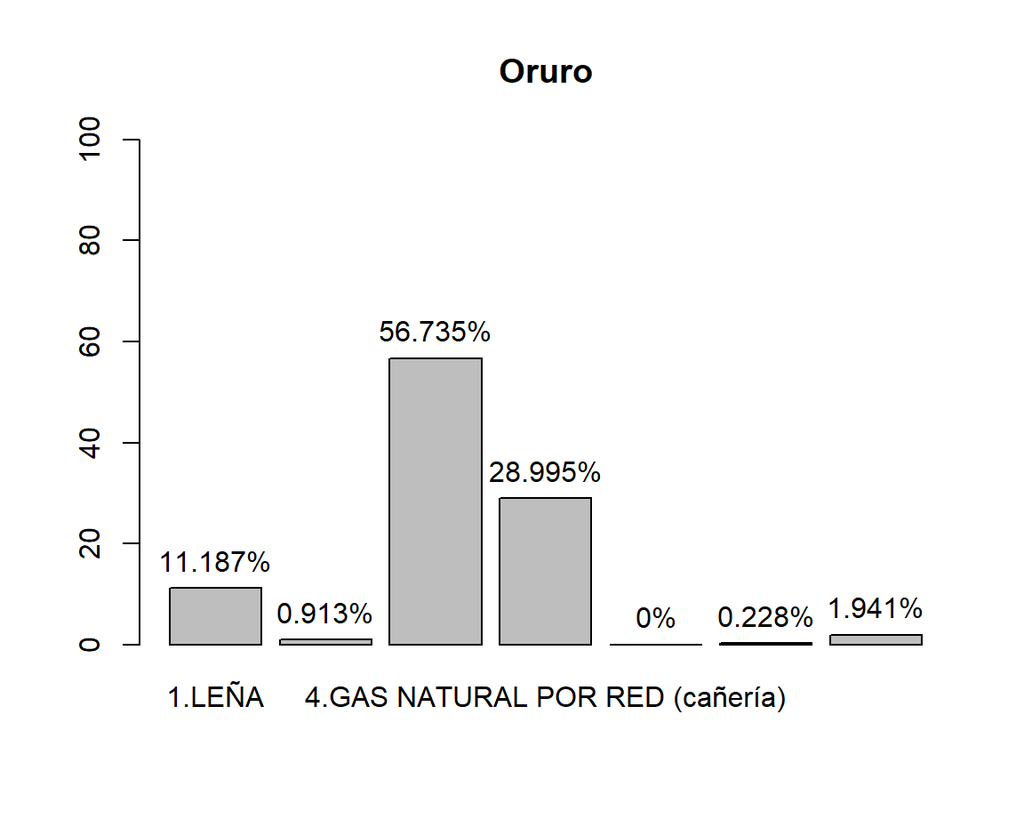

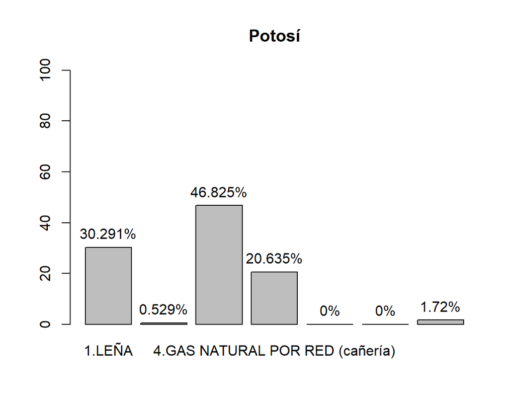

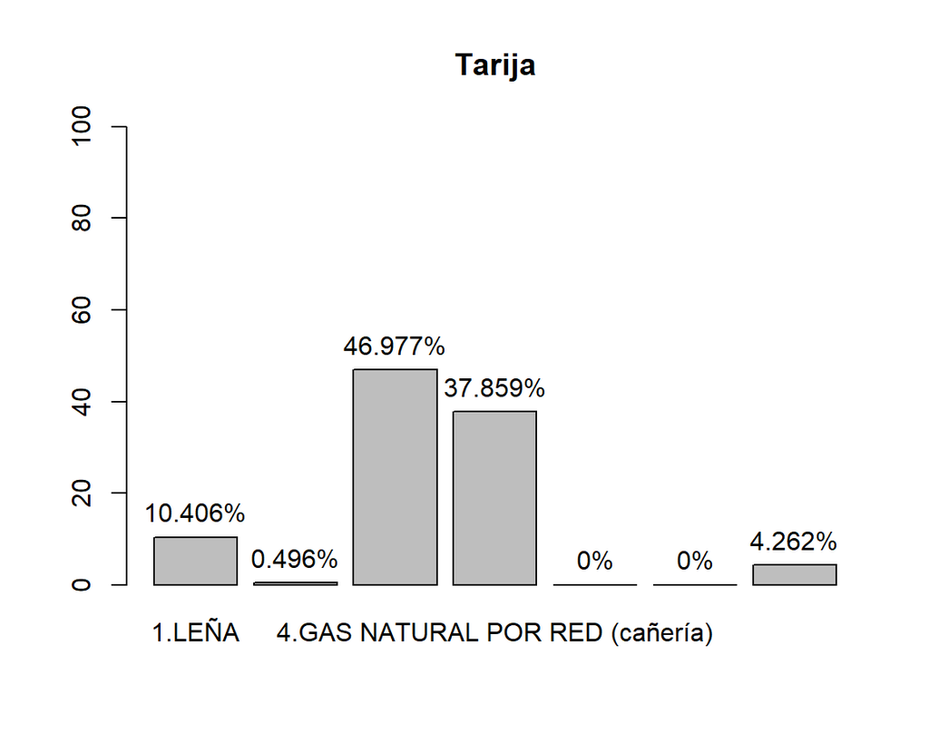

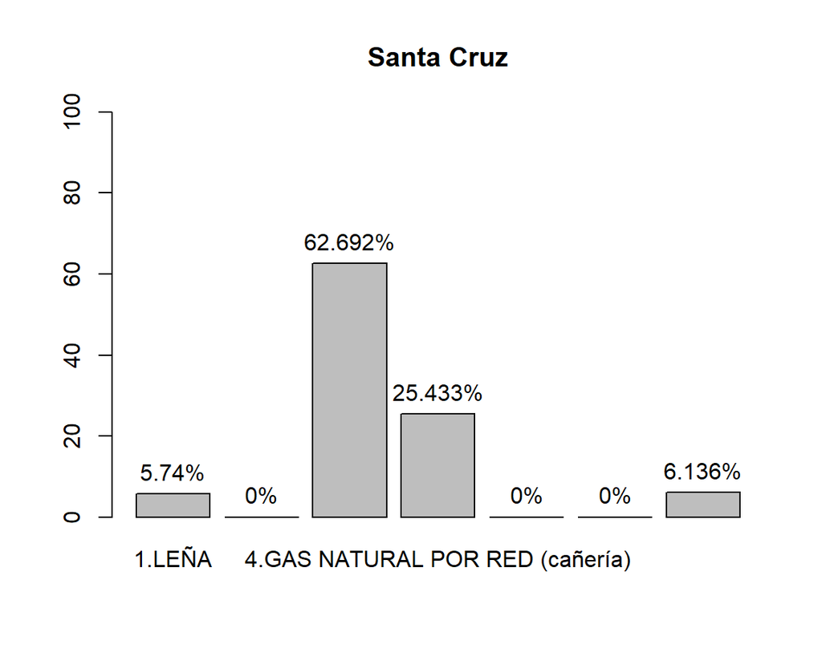

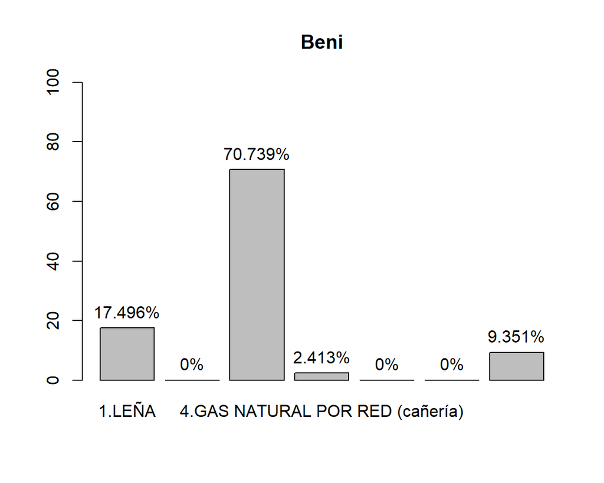

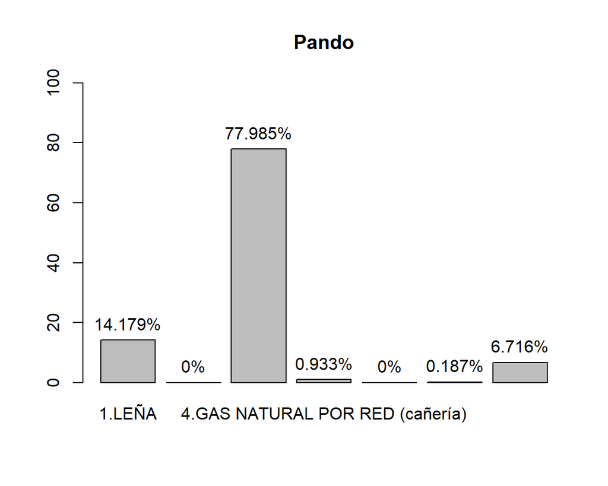

### FICHA TECNICA

**10. RELACIÓN ENTRE TIPO DE COMBUSTIBLE O ENERGÍA QUE SE UTILIZA PARA COCINAR (25) SEGÚN DEPARTAMENTO**

*NOMBRE DEL INDICADOR:* Tipo de combustible para cocinar según el departamento. *SIGLA DEL INDICADOR:* Viv_10 *OBJETIVO:* Determinar el porcentaje de los tipos de combustible o energía que se utiliza para cocinar/preparar alimentos según el departamento. *VARIABLES:* La construcción del indicador considera dos variables (pregunta) del cuestionario.

- Principalmente ¿qué tipo de combustible o energía utiliza para cocinar/ preparar sus alimentos?
  1. Leña
  2. Guano/bosta o taquia
  3. Gas licuado (garrafa)
  4. Gas natural por red (cañería)
  5. Otro
  6. Electricidad
  7. No cocina
- depto

*DESCRIPCIÓN DEL INDICADOR:* El indicador refleja el porcentaje del tipo de combustible o energía para cocinar con las que cuentan estas viviendas dependiendo del departamento donde estas se ubiquen. *MÉTODO DE MEDICIÓN:* El método de medición de este indicador se realizará a través de una tabla de frecuencias, ya que este es una variable cualitativa, en la tabla de frecuencias hallaremos el porcentaje de cada una de estas opciones. *FÓRMULA DE CÁLCULO:*
$$f_i = n_i/N$$
$$P_i = f_i*100$$
Donde:

fi = Es la frecuencia relativa

ni = Es la frecuencia absoluta

N = Es el número total de observaciones

Pi = Es el porcentaje de cada observación

### ANÁLISIS

Veamos los tres principales departamentos con mayor población.

La Paz

- El porcentaje que se utiliza para cocinar/preparar alimentos por medio de gas licuado (garrafa) es mayor al porcentaje de gas natural por red (cañería), pero tenemos que tener en cuenta que en el área rural no hay gas natural por red, lo cual influye.

Cochabamba

- El porcentaje que se utiliza para cocinar/preparar alimentos por medio de gas licuado (garrafa) es mayor al porcentaje de gas natural por red (cañería), pero tenemos que tener en cuenta que en el área rural no hay gas natural por red, lo cual influye.
- El 2.644 % representa que en la vivienda no se cocina.

Santa Cruz

- El porcentaje que se utiliza para cocinar/preparar alimentos por medio de gas licuado (garrafa) es mayor al porcentaje de gas natural por red (cañería), pero tenemos que tener en cuenta que en el área rural no hay gas natural por red, lo cual influye.

Entre los tres departamentos, Santa Cruz es la ciudad con mayor porcentaje que utiliza el gas licuado (garrafa) para preparar alimentos en la vivienda.

# IND 11

```
, ,  = Chuquisaca


                                          Urbana Rural
  1.Baño o letrina con descarga de agua     6.13  1.12
  2.Letrina de pozo ciego con piso          0.58  2.92
  3.Pozo abierto (pozo ciego sin piso)      0.34  1.34
  4.Baño ecológico (seco o de compostaje)   0.00  9.46
  5.Ninguno (Arbusto/Campo)                 2.16 20.77

, ,  = La Paz


                                          Urbana Rural
  1.Baño o letrina con descarga de agua    27.14  0.57
  2.Letrina de pozo ciego con piso         14.56  7.21
  3.Pozo abierto (pozo ciego sin piso)      3.35 14.41
  4.Baño ecológico (seco o de compostaje)  12.16 17.57
  5.Ninguno (Arbusto/Campo)                 1.80  6.03

, ,  = Cochabamba


                                          Urbana Rural
  1.Baño o letrina con descarga de agua    16.19  0.61
  2.Letrina de pozo ciego con piso         22.54  5.06
  3.Pozo abierto (pozo ciego sin piso)     10.55 13.23
  4.Baño ecológico (seco o de compostaje)   4.05  5.41
  5.Ninguno (Arbusto/Campo)                 1.53 10.07

, ,  = Oruro


                                          Urbana Rural
  1.Baño o letrina con descarga de agua     4.97  0.26
  2.Letrina de pozo ciego con piso          2.73  2.63
  3.Pozo abierto (pozo ciego sin piso)      1.01  3.52
  4.Baño ecológico (seco o de compostaje)   0.00  1.35
  5.Ninguno (Arbusto/Campo)                 4.95 23.65

, ,  = Potosí


                                          Urbana Rural
  1.Baño o letrina con descarga de agua     4.00  1.07
  2.Letrina de pozo ciego con piso          0.34  3.41
  3.Pozo abierto (pozo ciego sin piso)      0.50  2.68
  4.Baño ecológico (seco o de compostaje)   0.00 12.16
  5.Ninguno (Arbusto/Campo)                 1.53 20.41

, ,  = Tarija


                                          Urbana Rural
  1.Baño o letrina con descarga de agua     8.34  1.68
  2.Letrina de pozo ciego con piso          2.63  4.53
  3.Pozo abierto (pozo ciego sin piso)      1.17  2.18
  4.Baño ecológico (seco o de compostaje)   0.00  4.05
  5.Ninguno (Arbusto/Campo)                 0.18  2.88

, ,  = Santa Cruz


                                          Urbana Rural
  1.Baño o letrina con descarga de agua    19.62  1.01
  2.Letrina de pozo ciego con piso          6.77  3.16
  3.Pozo abierto (pozo ciego sin piso)      6.37 12.56
  4.Baño ecológico (seco o de compostaje)   5.41  9.46
  5.Ninguno (Arbusto/Campo)                 0.09  3.15

, ,  = Beni


                                          Urbana Rural
  1.Baño o letrina con descarga de agua     3.98  0.42
  2.Letrina de pozo ciego con piso          7.01  3.99
  3.Pozo abierto (pozo ciego sin piso)      5.19  5.53
  4.Baño ecológico (seco o de compostaje)  12.16  5.41
  5.Ninguno (Arbusto/Campo)                 0.27  0.27

, ,  = Pando


                                          Urbana Rural
  1.Baño o letrina con descarga de agua     2.59  0.30
  2.Letrina de pozo ciego con piso          3.60  6.33
  3.Pozo abierto (pozo ciego sin piso)      5.86 10.22
  4.Baño ecológico (seco o de compostaje)   1.35  0.00
  5.Ninguno (Arbusto/Campo)                 0.18  0.09
```

[figure not shown]

[figure not shown]

[figure not shown]

[figure not shown]

[figure not shown]

[figure not shown]

[figure not shown]

[figure not shown]

[figure not shown]

**FICHA TECNICA**

11. RELACIÓN ENTRE TIPO DE BAÑO O LETRINA QUE UTILIZAN NORMALMENTE LOS MIEMBROS DE SU HOGAR (15) SEGÚN ÁREA, POR DEPARTAMENTO.

*NOMBRE DEL INDICADOR:* Tipo de baño o letrina según el área por departamento. *SIGLA DEL INDICADOR:* Viv_11 *OBJETIVO:* Determinar el porcentaje de los tipos de baños, servicios sanitarios o letrinas que utilizan por área, según el departamento elegido. *VARIABLES:* La construcción del indicador considera dos variables (pregunta) del cuestionario.

- ¿Qué tipo de baño, servicio sanitario o letrina utilizan normalmente los miembros de su hogar?
  1. Baño o letrina con descarga de agua
  2. Letrina de pozo ciego con piso
  3. Pozo abierto (pozo ciego sin piso)
  4. Baño ecológico (seco o de compostaje)
  5. Ninguno (Arbusto/Campo)
- Área
- depto

*DESCRIPCIÓN DEL INDICADOR:* El indicador refleja el porcentaje del tipo de baño, servicio sanitario o letrina utilizan normalmente las viviendas dependiendo del área, según el departamento elegido. *MÉTODO DE MEDICIÓN:* El método de medición de este indicador se realizará a través de una tabla de frecuencias, ya que este es una variable cualitativa, en la tabla de frecuencias hallaremos el porcentaje de cada una de estas opciones, para cada departamento. *FÓRMULA DE CÁLCULO:*
$$f_i = n_i/N$$

$$P_i = f_i*100$$
Donde:

fi = Es la frecuencia relativa

ni = Es la frecuencia absoluta

N = Es el número total de observaciones

Pi = Es el porcentaje de cada observación

**ANÁLISIS**

La Paz

Cochabamba

Santa Cruz